# ex2

in the name of allah

dsigned by hussein zahaki

hussein.zahaki.mansoor@gmail.com

-

-

-

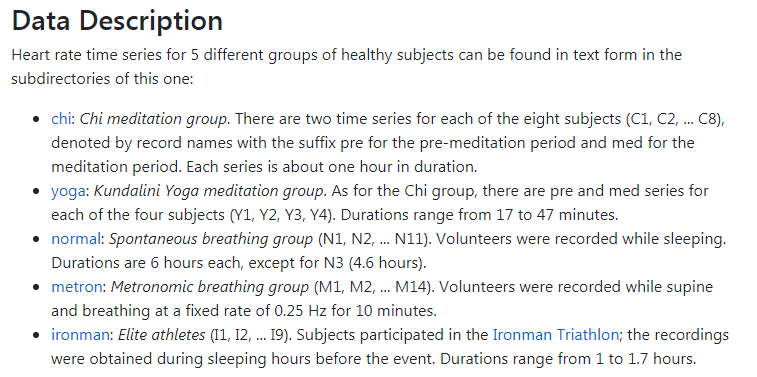

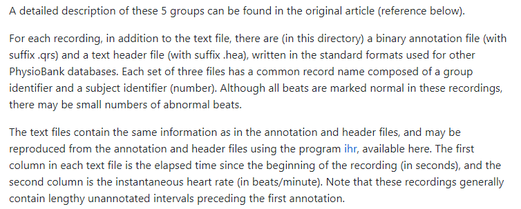

## Electrocardiography

Electrocardiography is the process of producing an electrocardiogram (ECG or EKG[a]). It is a graph of voltage versus time of the electrical activity of the heart[4] using electrodes placed on the skin

There are three main components to an ECG: the P wave, which represents the depolarization of the atria; the QRS complex, which represents the depolarization of the ventricles; and the T wave, which represents the repolarization of the ventricles.

[for more information click here](https://en.wikipedia.org/wiki/Electrocardiography)

[figure not shown]

link to [database](https://physionet.org/content/meditation/1.0.0/)

We report extremely prominent heart rate oscillations associated with slow breathing during specific traditional forms of Chinese Chi and Kundalini Yoga meditation techniques in healthy young adults. We applied both spectral analysis and a novel analytic technique based on the Hilbert transform to quantify these heart rate dynamics. The amplitude of these oscillations during meditation was significantly greater than in the pre-meditation control state and also in three non-meditation control groups: i) elite athletes during sleep, ii) healthy young adults during metronomic breathing, and iii) healthy young adults during spontaneous nocturnal breathing. This finding, along with the marked variability of the beat-to-beat heart rate dynamics during such profound meditative states, challenges the notion of meditation as only an autonomically quiescent state.

## Introduction

There has been much interest in heart rate dynamics during a variety of physiological and pathological states. In addition, considerable attention has been focused on the potential health benefits of a variety of meditative, relaxation techniques and their possible effects on neuroautonomic function. Surprisingly, however, there is little information regarding the effects of meditation on beat-to-beat heart rate dynamics as an indirect ``assay'' of autonomic regulation [1,2,3]. Accordingly, we collected and analyzed continuous heart rate time series from two groups of healthy young adults before and during two well-known forms of meditation. We sought to determine 1) whether there are any distinctive heart rate dynamics during these practices, and 2) whether such meditative states induce a quiescent (less variable) or active (more variable) pattern of autonomic response.

# Materials and Methods

## Subjects and Meditation Protocols

Two specific meditative techniques were studied: (i) Chinese Chi (or Qigong) meditation (as taught by Xin Yan) and (ii) Kundalini Yoga meditation (as taught by Yogi Bhajan).  
The Chi meditators were all graduate and post-doctoral students. They were also relative novices in their practice of Chi meditation, most of them having begun their meditation practice about 1-3 months before this study. The Kundalini Yoga subjects were considered to be at an advanced level of meditation training. The subjects of both meditation groups were in good general health and did not follow any specific exercise routines. All subjects provided informed consent in accord with a protocol approved by the Beth Israel Deaconess Medical Center Institutional Review Board.  
The eight Chi meditators, 5 women and 3 men (age range 26-35, mean 29 yrs), wore a Holter recorder for approximately 10 hours during which time they went about their ordinary daily activities. At approximately 5 hours into the recording they each practiced one hour of meditation. Meditation beginning and ending times were delineated with event marks.  
During these sessions, the Chi meditators sat quietly, listening to the taped guidance of the Master. The meditators were instructed to breath spontaneously while visualizing the opening and closing of a perfect lotus in the stomach. The meditation session lasted about one hour.  
The four Kundalini Yoga meditators, 2 women and 2 men (age range 20-52, mean 33 yrs), wore a Holter monitor for approximately one and half hours. 15 minutes of baseline quiet breathing were recorded before the 1 hour of meditation. The meditation protocol consisted of a sequence of breathing and chanting exercises, performed while seated in a cross-legged posture. The beginning and ending of the various meditation sub-phases were delineated with event marks.  
In addition to comparing the pre-meditation and meditation states, we also made comparisons to three healthy, non-meditating control groups from a database of retrospective electrocardiogram (ECG) signals: (i) A spontaneously breathing group of 11 healthy subjects (8 women and 3 men; age range 20-35, mean 29) during sleeping hours. (ii) A healthy group of 14 subjects (9 women and 5 men; age range 20-35, mean 25) during supine metronomic breathing at 0.25 Hz. (iii) A group of 9 elite triathlon athletes in their pre-race period (3 women and 6 men; age range 21-55, mean 39) during sleeping hours. Except for exercise training in the triathlon athlete group, the overall general health conditions for the meditation groups and control groups were comparable.

## Signal Processing and Data Analysis

The Holter tapes were scanned and annotated using a Marquette Electronics Model 8000T Holter scanner and annotations manually verified. The resulting annotation files were then transferred to a Sparc workstation for further analysis. A small fraction (< 1%) of the instantaneous RR interval heart rate time series for each recording was identified as outliers and deleted. Instantaneous heart rate time series were then derived by taking the inverse of each successive interbeat interval.  
We applied an ECG-derived respiration algorithm [4,5] to obtain information about the frequency and relative amplitude of respiration. [Briefly, this technique is based on the observation that the body surface ECG is influenced by electrode motion relative to the heart and by changes in thoracic electrical impedance as the lungs fill and empty](https://en.wikipedia.org/wiki/Electrocardiography). Measurement of axis shifts at each normal QRS interval provide a continuous ECG-derived respiration signal. The relation between this signal and respiration has been confirmed by comparing the changes in axis direction with simultaneous measurements of chest circumference taken with a mercury strain gauge or pneumatic respiration transducer [5]. We cross-correlated the heart rate time series with the ECG-derived respiration signal. In particular, we uniformly resampled both the instantaneous heart rate and the ECG-derived respiration time series at 2 Hz, then calculated the coherence [6] of these two signals.  
To quantify the amplitudes of heart rate oscillations during meditation and to compare them with those under usual basal conditions, two independent quantitative algorithms have been applied:  
(1) We calculated Fourier spectral power by applying the Lomb periodogram method for unevenly sampled data [6]. Spectral power was measured in the frequency range 0.025-0.35 Hz to ensure that all respiration related heart rate oscillations would be included.  
(2) We also used a Hilbert transform-based algorithm [7,8]. The advantages of using the Hilbert transform are two-fold: (i) it does not require stationarity of the signal; and (ii) it measures the amplitude and frequency of the dominant oscillation in the signal at each moment. However, since the Hilbert transform can be applied only on narrow band signals, the heart rate time series has to be pre-processed. First, the heart rate time series signal was bandpass filtered over the same frequency range (0.025 to 0.35 Hz) studied in the Fourier analysis. Next, a Hilbert transformation was performed on the filtered signal. Thus for each subject's heart rate time series, we obtained a sequence of amplitudes describing the time-dependent magnitude of the oscillations.  
We then calculated the median value, Am, of the oscillation amplitude obtained by the Hilbert transform for each subject. The median value is a robust measurement even when a substantial number of outliers are present in the data. The Hilbert transform and median amplitude procedure described here can be applied to time series with an arbitrary number of data points. Therefore, the results can be compared among subjects with data sets of different lengths.

## Statistical Analysis

To determine the effect of meditation on oscillation amplitude and spectral power in the meditators, values measured before and during meditation were compared using a paired t-test. The Student t-test was used to compare values obtained during meditation to those obtained from each control group. A p value of less than 0.01 (two-sided) was used as the level of significance for rejecting the null hypothesis that values measured during meditation were similar to those obtained outside of meditation. Since the number of subjects in each meditation group was small, we pooled these subjects (n=12) for the comparisons with the control groups. Statistical analysis was performed using SAS software release 6.12 (Cary, North Carolina). Results are reported as mean standard deviation.

## Results

Figure 1 shows representative instantaneous heart rate plots for one Chi meditator and one Kundalini meditator. Two features stand out: 1) The extremely prominent heart rate oscillations for both subjects during meditation. Spectral analysis of these heart rate time series confirmed a peak in the range of 0.025-0.35 Hz for both groups of meditators. For example, Figure 2 shows illustrative data from another Chi meditator with a spectral peak around 0.05 Hz. 2) The overall variability of the time series. The heart rate dynamics typically showed highly complicated fluctuations, rather than a quiescent ``steady state.''  
To test the hypothesis that these extremely large amplitude oscillations were related to breathing, we studied the cross-correlation between the heart rate and ECG-derived respiration signals. Figure 3 shows the Fourier analysis of one subject's heart rate and ECG-derived respiration signals. The coherence measurement verifies that these heart rate oscillations are closely related to respiration.  
Table 1 shows the group averaged measurements of median heart rate oscillation amplitude calculated using the Hilbert transform method. During meditation, the two meditation groups both had significantly greater amplitude of heart rate oscillations compared to their pre-meditation baselines, and to the other control groups. However, there was no significant difference in the heart rate oscillation amplitude between the pre-meditation subjects and healthy controls during spontaneous breathing.  
Results of Fourier analysis, shown in Table 1, are consistent with the Hilbert derived powers. The frequency range we studied here roughly spans the low frequency (usually 0.04-0.15 Hz) and high frequency (usually 0.15-0.4 Hz) bands typically used in the literature. Therefore, the Fourier powers of this study (as well as the Hilbert powers Am2/2), can only be approximately compared to the sum of power in low frequency and high frequency bands in most other studies. Furthermore, the Hilbert derived power corresponds most precisely to the actual power of the observed oscillations of interest in the present study. Finally, we note that when comparing Hilbert and Fourier powers, the former are consistently lower because they are based on a single predominant frequency of interest, whereas the latter encompass all frequency components within a given band.

## Discussion

The major and unexpected finding in this analysis of heart rate dynamics during these two forms of meditation in a small number of subjects was the presence of intermittent, extremely prominent oscillations in the 0.025-0.35 Hz band. For example, as shown in Figure 1, the heart rate varied over a 30-35 beat/min range within 5 sec in some of the subjects. These oscillations, observed in both Chi and Kundalini practitioners, correlated with slow breathing. Of note, these oscillations were significantly larger in amplitude than the variations associated with respiratory sinus arrhythmia observed during the pre-meditation control state, and other healthy young adults during metronomic or nocturnal breathing, as well as in elite triathlon athletes during sleep. Also of note was the highly complex nature of the fluctuations for the overall time series during the meditative states (Fig. 1).  
These findings appear to contradict a conventional notion of meditation as only a psychologically and physiologically quiescent (``homeostatic'') state. Instead, the selected healthy individuals we studied showed marked dynamic variability in heart rate during a state subjectively perceived as one of profound relaxation. These findings raise several intriguing questions, including: 1) Do some forms of meditation involve a type of autonomic ``exercise'' mediated, at least in part, by specialized breathing maneuvers? 2) To what extent does the magnitude of heart rate oscillations relate to the rate and depth of respiration? 3) Are there ``universal'' physiological mechanisms involved in certain types of meditative states that are triggered by apparently disparate protocols developed in different cultures?  
To answer the above questions, future studies should also include other useful physiologic signals, e.g., direct measurement of respiration and blood pressure. Further systematic, quantitative analysis of cardiopulmonary dynamics in a large number of healthy subjects in different age groups, as well as those with a variety of pathologic conditions, before, during and after various meditation regimes should broaden our understanding of an important class of mind-body interactions.

1-Corby JC, Roth WT, Zarcone VP Jr, Kopell BS. Psychophysiological correlates of the practice of Tantric Yoga meditation. Arch Gen Psychiatry 1978;35:571-577.  
2-Gallois P. Modifications neurophysiologiques et respiratoires lors de la pratique des techniques de relaxation. Encephale 1984;10:139-144.  
3-Sakakibara M, Takeuchi S, Hayano J. Effect of relaxation training on cardiac parasympathetic tone. Psychophysiology 1994;31:223-228.  
4-Lipsitz LA, Hashimoto F, Lubowsky LP, Mietus JE, Moody GB, Appenzeller O, Goldberger AL. Heart rate and respiratory rhythm dynamics on ascent to high altitude. Br Heart J 1995;74:390-396.  
5-Moody GB, Mark RG, Zoccola A, Vergani L. Derivation of respiratory signals from multilead ECGs. Computers in Cardiology, IEEE 1985;12:113-116.  
6-Press WH, Teukolsky SA, Vetterling WT, Flannery BP. Numerical recipes in C: the art of scientific computing, 2nd edition. New York: Cambridge University Press, 1992.  
7-Cohen L. Time frequency analysis. Englewood Cliffs, NJ: Prentice-Hall, 1995.  
8-Ivanov PCh, Rosenblum MG, Peng C-K, Mietus J, Havlin S, Stanley HE, Goldberger AL. Scaling behaviour of heartbeat intervals obtained by wavelet-based time-series analysis. Nature 1996;383:323-327.

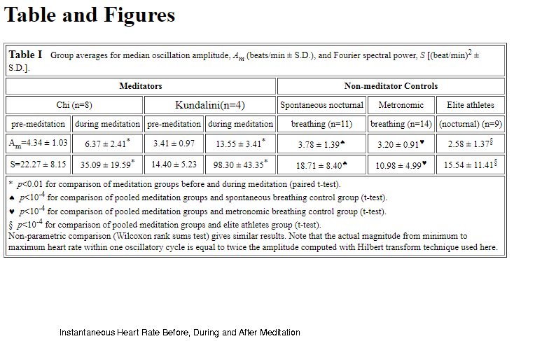

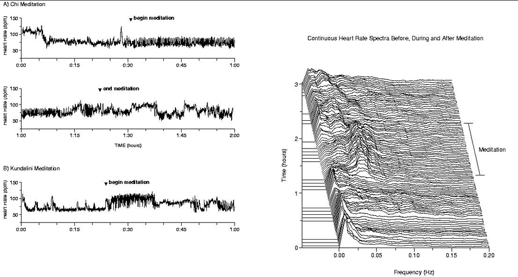

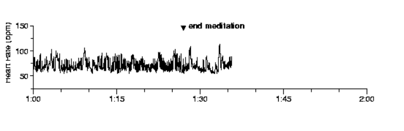

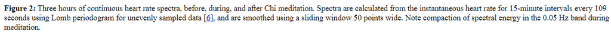

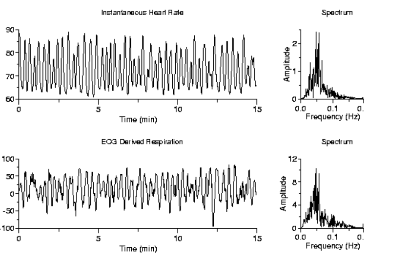

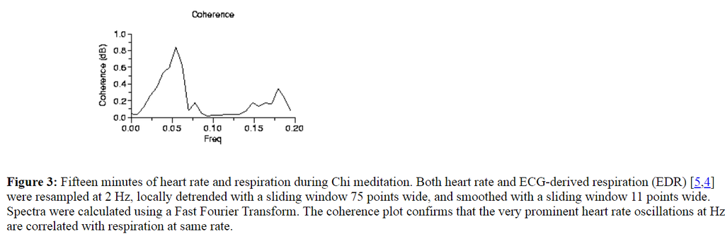

```python
import matplotlib.pyplot as plt
%matplotlib inline
import numpy as np
from scipy.fftpack import fft
import pandas as pd

from sklearn.model_selection import train_test_split
from sklearn.neighbors import KNeighborsClassifier
from sklearn.linear_model import LogisticRegression
from sklearn.tree import DecisionTreeClassifier
from sklearn import preprocessing

from mglearn.plots import plot_2d_separator
from mglearn import discrete_scatter
```

## First step: Gathering information from the Heart Rate Oscillations during Meditation database and use it as a pandas data frame

```python
# ironman and metron files must be converted to pandas usable data frame
for addrss, name, num, indent  in zip([ 'ironman/','metron/'],
                                    ['I','M'],
                                    [ 10, 15],
                                    ['	    ','	    ']) :
    for i in range (1, num):
        with open(addrss + name + str(i)  , 'r') as file:
            st = file.read().replace('\t    ', ' ').replace('\t   ', ' ')
        with open('C' + addrss + name + str(i)  , 'w') as file:
            file.write(st)
        del(st)



plt.rcParams['figure.max_open_warning'] = 80
plt.rcParams["figure.figsize"]=8,8
data_arr = {}
for addrss, name, num, suffix, indent  in zip(['chi/', 'Cironman/','Cmetron/','normal/','yoga/'],
                                    ['C','I','M','N','Y'],
                                    [9, 10, 15, 12, 5],
                                    [['.pre','.med'],['',''],['',''], ['',''], ['.pre','.med']],
                                    [' ', ' ',' ',' ',' ']) :
    for i in range (1, num):
        tmp =  name + str(i) + suffix[0]
        pre = data_arr[tmp] = pd.read_csv( addrss + tmp, '\n', indent, names = ['time','data'], engine='python')
        min_val = min(pre['time'])
        pre['time'] = (pre['time'] - min_val)

        if len(suffix[1]):
                tmp = name + str(i) + suffix[1]
                med = data_arr[tmp] = pd.read_csv(addrss + tmp, '\n', indent, names = ['time','data'], engine='python')
                min_val = min(med['time'])
                med['time'] = (med['time'] - min_val)
```

## Second step: calculating frequency domain of Gathered information from the Heart Rate Oscillations during Meditation database and use it as a pandas data frame

```python
#calculating frequency domain
fs = 128 #Hz
spectral_arr = {}
for instance  in  data_arr.keys():
    df= pd.DataFrame()

    data = data_arr[instance]['data'].values
    time = data_arr[instance]['time'].values

    #deleting DC signal from data
    data = data - np.mean(data)
    high_freq = 1 #Hz
    cuttoff_freq = 128/high_freq #fs/2Hz
    freq_vect = np.linspace(0.0, 1.0,int(len(data)/cuttoff_freq)) * fs/cuttoff_freq #2Hz maximum

    #FFT of Signal
    DATA = abs(fft(data)[0 : int(len(data)/cuttoff_freq)]) * 2/len(data)
    df['axis'] = freq_vect;  df['domain'] = DATA
    spectral_arr[instance] = df

    #note for normalization we must take care about number of data in data_arr
    #note the number of data in data_arr must be equal to size of fft buffer
```

## Now it's time to paint!

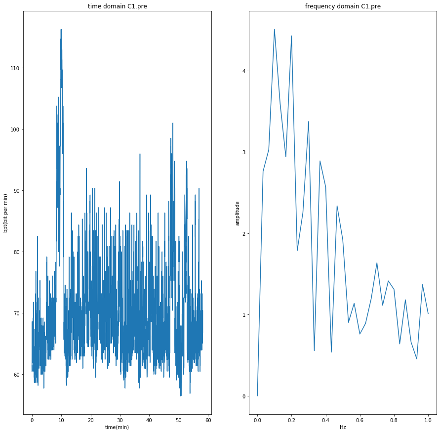

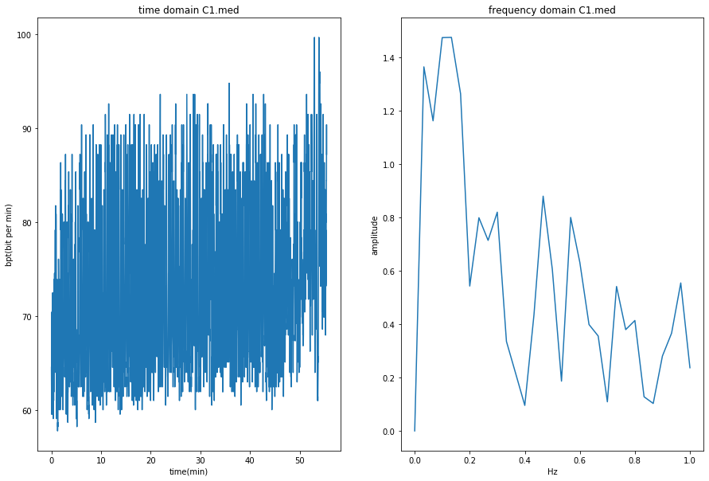

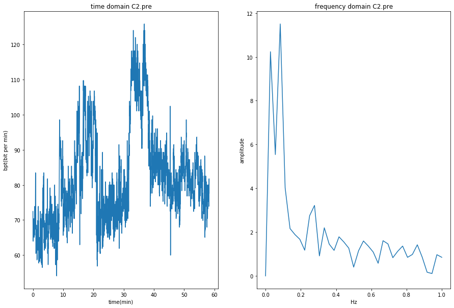

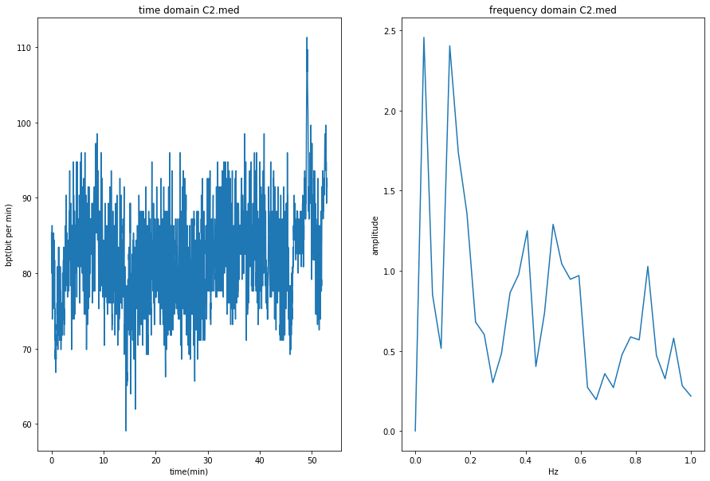

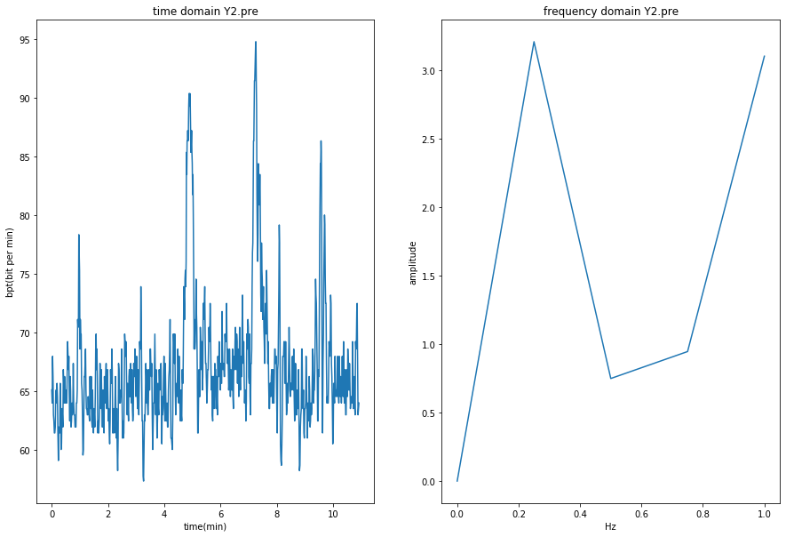

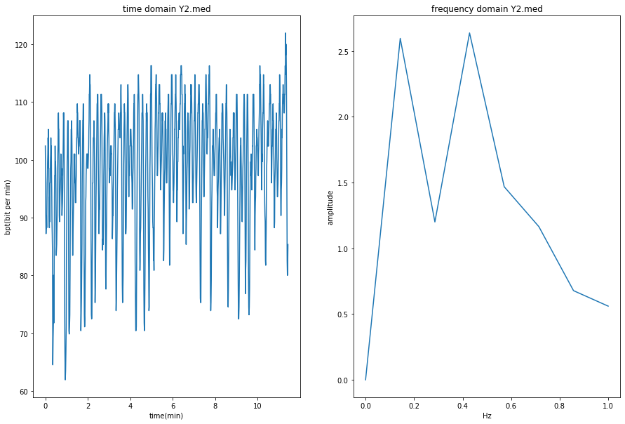

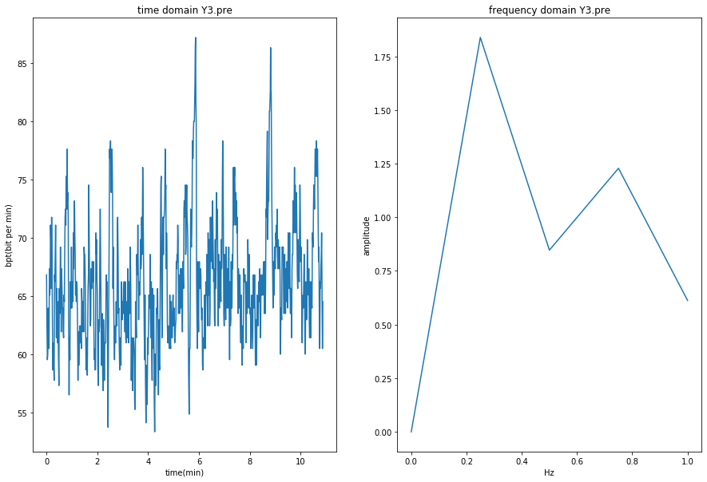

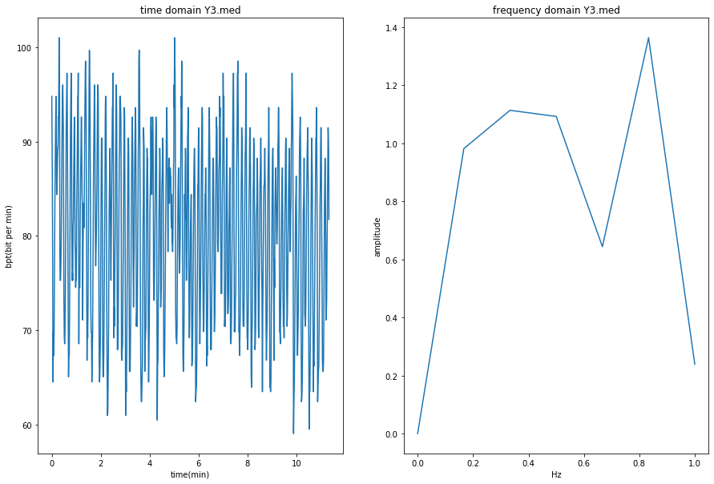

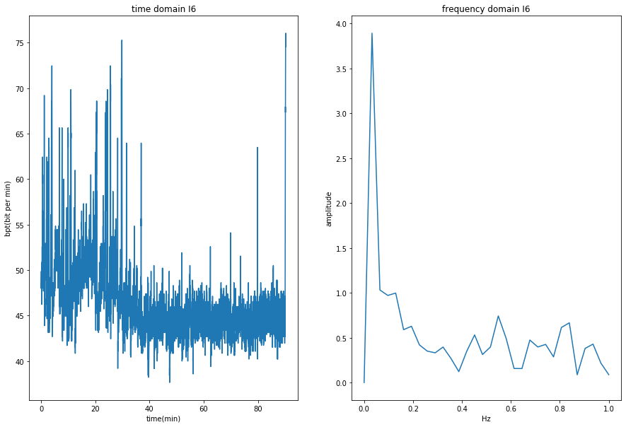

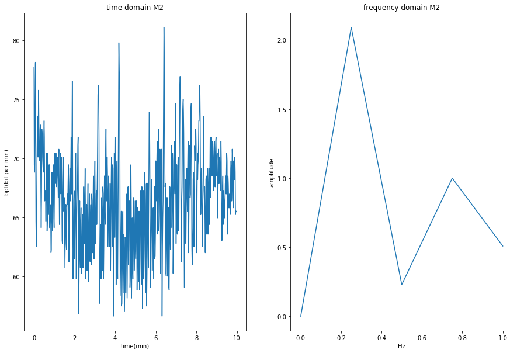

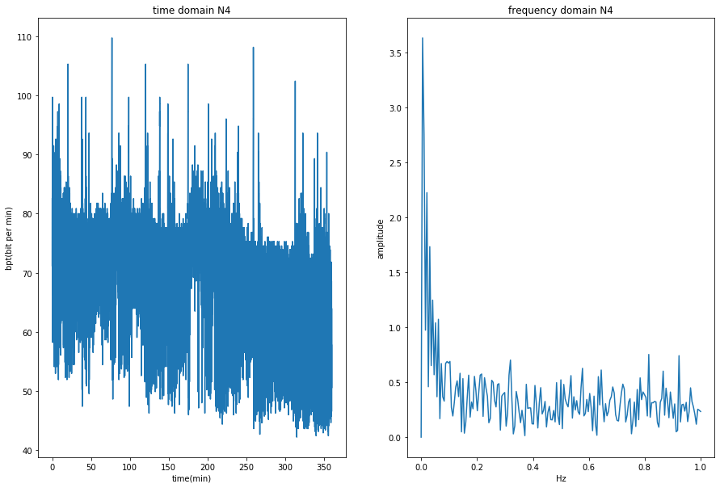

```python
#data_arr
#spectral_arr


def paintToScratch( name, dataFrame = data_arr, spectralFrame = spectral_arr):
    dataFrame = dataFrame[name]; spectralFrame = spectralFrame[name]
    plt.figure()
    plt.rcParams["figure.figsize"]=15,10

    plt.subplot(1,2,1); plt.plot(dataFrame['time']/60 ,dataFrame['data'])
    plt.title('time domain'+ ' ' + name ); plt.xlabel('time(min)'); plt.ylabel('bpt(bit per min)')
    plt.subplot(1,2,2); plt.plot(spectralFrame['axis'], spectralFrame['domain'])
    plt.title('frequency domain' +' ' + name ); plt.xlabel('Hz'); plt.ylabel('amplitude')

paintToScratch( 'C1.pre' )
paintToScratch( 'C1.med' )

paintToScratch( 'C2.pre' )
paintToScratch( 'C2.med' )

paintToScratch( 'Y2.pre' )
paintToScratch( 'Y2.med' )

paintToScratch( 'Y3.pre' )
paintToScratch( 'Y3.med' )

paintToScratch( 'I6' )

paintToScratch( 'M2' )

paintToScratch( 'N4' )
```

## Now it's time for the machine to learn!

we change features and targets in follow way(model 0)  
this is a classification problem to finding maditators during meditation We defined the features and target names as follows:  
features: frequency domain, time domain  
target names: meditator, normal  
Note that the Heart Rate Oscillations during Meditation database collected 58 instance and it must be shuffled before training

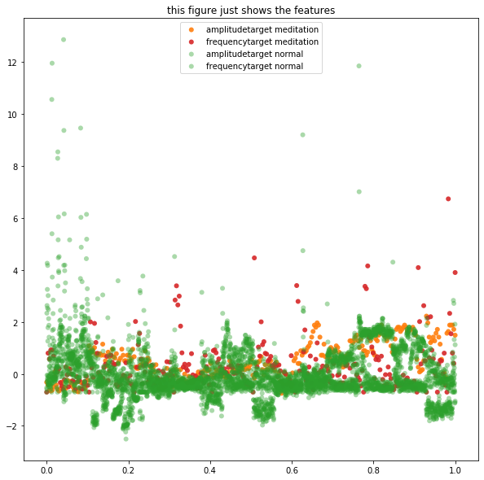

```python
#reshaping to sklearn standard data set
#note for normalization we must take care about number of data in data_arr
#note the number of data in data_arr must be equal to size of fft buffer
#[amp, freq]

data = []
for instance in data_arr.keys():
    for amp,freq in zip(data_arr[instance]['data'], spectral_arr[instance]['domain']):
        data.append([amp, freq, (len(instance) > 2 and  instance[3:] == 'med') * 1 ])
data = np.array(data)
#normalize amp:
data[:,0] =  data[:,0] -  np.mean(data[:,0])
data[:,1] =  data[:,1] * 100

meditation_dataset = {
    'data': preprocessing.scale(data[:, 0:2]), #[amp, freq]
    'target': data[:, 2].astype('int') ,
    'feature_name':['amplitude', 'frequency'],
    'target_name':['normal', 'meditator']
}
#see the result



data_med = meditation_dataset['data'][(meditation_dataset['target']==1)]
data_norm = meditation_dataset['data'][(meditation_dataset['target']==0)]

tar_range = np.linspace(0,1,np.sum(meditation_dataset['target']==1))
ax = plt.subplots(figsize=(10,10))[1]


for j,col in zip( range( len(meditation_dataset['feature_name']) ), ['tab:orange', 'tab:red'] ):
        title = meditation_dataset['feature_name'][j]
        ax.scatter(tar_range, data_med[:, j] , label=title + 'target meditation',
                   alpha=0.9, c=col,  edgecolors='none')

tar_range = np.linspace(0,1,np.sum(meditation_dataset['target']==0))


for j,col in zip( range( len(meditation_dataset['feature_name']) ), ['tab:green', 'tab:blue'] ):
        title = meditation_dataset['feature_name'][j]
        ax.scatter(tar_range, data_norm[:, j] , label=title + 'target normal',
                   alpha=0.4, c=color,  edgecolors='none')

plt.legend()
plt.title('this figure just shows the features')
plt.show()
```

### --finding the Sweet Spot with KNN classifier

|  | trainScore | testScore | neighborRange | bestNeighbor |
| --- | --- | --- | --- | --- |
| 0 | 100.0% | 84.37935843793585% | 1 |  |
| 1 | 92.27547696603071% | 89.40027894002789% | 2 |  |
| 2 | 92.04281060958586% | 87.58716875871687% | 3 |  |
| 3 | 90.87947882736157% | 89.40027894002789% | 4 |  |
| 4 | 90.92601209865053% | 89.1213389121339% | 5 |  |
| 5 | 90.36761284318288% | 89.8186889818689% | 6 |  |
| 6 | 90.36761284318288% | 89.9581589958159% | 7 |  |
| 7 | 90.36761284318288% | 89.8186889818689% | 8 |  |
| 8 | 90.36761284318288% | 89.5397489539749% | 9 |  |
| 9 | 89.99534667287111% | 90.2370990237099% | 10 | The best choices |
| 10 | 89.99534667287111% | 89.8186889818689% | 11 |  |
| 11 | 89.6696137738483% | 89.8186889818689% | 12 |  |
| 12 | 89.53001395998139% | 89.5397489539749% | 13 |  |
| 13 | 89.71614704513728% | 89.6792189679219% | 14 |  |
| 14 | 89.53001395998139% | 89.40027894002789% | 15 |  |
| 15 | 89.57654723127035% | 89.6792189679219% | 16 |  |
| 16 | 89.39041414611447% | 89.5397489539749% | 17 |  |
| 17 | 89.39041414611447% | 89.40027894002789% | 18 |  |
| 18 | 89.53001395998139% | 89.6792189679219% | 19 |  |

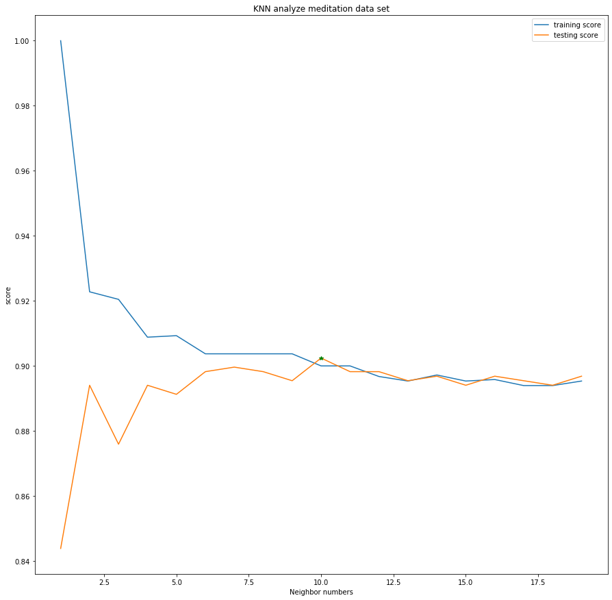

```python
#simple ' Array Extender function' used in KNN_DataSetAnalyzer  func
#args format: desiredIndex0, desiredIndex1,..
def extendArr(lenOfArray, _index):
    ref = [''] * lenOfArray
    for i in _index:
        ref[i] = "The best choices"
    return ref


""" :brief  This function is used to find the location of a particular member in an array
    :param arr:
        input array
    :param search:
        In fact, this is the parameter we want to find its position in the array.
"""
def findIndex(arr, search):
    last_index = -1
    indexRes = []
    while True:
        try:
            last_index = arr.index(search, last_index + 1)
            indexRes.append( last_index )
        except ValueError:
             break
    return indexRes


""" :brief  neigbor  DataSet Analyzer
    :param dataset:
        input data set
    :note Dataset content is determined by the type of used library
    :param libraryFormat:
        this param determines the type of input dataset
    :note, the libraryFormat suppoorted values:
            'klearn', 'mglearn'
    :param print_output:
        Using this feature, you can plot the ouput result on the screen
    :param plot_title:
        setting the title of plotted figure
    :retval is a pandas data frame that contains information about machine learning model
"""
def KNN_DataSetAnalyzer(dataset, libraryFormat = 'sklearn', print_output = True, plot_title = 'figure'):
    #defining variables
    neigbor_set = range(1,20)
    train_sec = []
    test_sec = []
    #the dataset must be shuffled before using
    if  libraryFormat == 'sklearn':
        dataset = [dataset['data'], dataset['target'] ]

    ml_model = {inp: val for inp,val in zip( ['Xtrain','Xtest','ytrain','ytest'],
                                                train_test_split(dataset[0] , dataset[1],random_state = 1) ) }

    #test and training our dataset in the KNN Classifier and calculate score of tested data
    for neigborNumber in neigbor_set:
        knn = KNeighborsClassifier(n_neighbors = neigborNumber).fit(ml_model['Xtrain'], ml_model['ytrain'])
        test_sec.append( knn.score(ml_model['Xtest'], ml_model['ytest']) )
        train_sec.append( knn.score(ml_model['Xtrain'], ml_model['ytrain']) )
    #finding the best neighbor number for generalization
    KNN_index =  findIndex(test_sec, max(test_sec))

    #(arbitrary)we can plot the model on our screen
    if(print_output):
        plt.rcParams["figure.figsize"]=15,15

        plt.figure()
        plt.title(plot_title)
        plt.plot(neigbor_set, train_sec, label = 'training score')
        plt.plot(neigbor_set, test_sec, label = 'testing score')
        plt.legend()
        plt.ylabel("score")
        plt.xlabel("Neighbor numbers")
        #inserting stars in desired positions
        for i in KNN_index:
            plt.plot(neigbor_set[i], test_sec[i], 'g*')

     #finally  our model reterned in 'pandas data frame' format
    return pd.DataFrame({'trainScore': map( (lambda x:( str(x*100)+'%') ),train_sec) ,
                         'testScore':  map( (lambda x:( str(x*100)+'%') ),test_sec),
                         'neighborRange' : neigbor_set,
                         'bestNeighbor': extendArr(len(test_sec), KNN_index)
                        })


# analyze data
knn_score = KNN_DataSetAnalyzer(meditation_dataset, plot_title = 'KNN analyze meditation data set')
display(knn_score)
```

### --finding the Sweet Spot with DecisionTree

|  | trainScore | testScore | tree_depth | best_tree_depth |
| --- | --- | --- | --- | --- |
| 0 | 89.39041414611447% | 89.9581589958159% | 1 | The best choices |
| 1 | 89.39041414611447% | 89.9581589958159% | 2 | The best choices |
| 2 | 89.39041414611447% | 89.9581589958159% | 3 | The best choices |
| 3 | 89.53001395998139% | 89.2608089260809% | 4 |  |
| 4 | 90.08841321544905% | 88.14504881450488% | 5 |  |
| 5 | 90.50721265704979% | 88.28451882845188% | 6 |  |
| 6 | 91.11214518380642% | 88.00557880055788% | 7 |  |
| 7 | 91.90321079571893% | 87.86610878661088% | 8 |  |
| 8 | 93.20614239181015% | 88.00557880055788% | 9 |  |
| 9 | 94.36947417403444% | 86.75034867503487% | 10 |  |
| 10 | 95.34667287110284% | 86.75034867503487% | 11 |  |
| 11 | 96.27733829688228% | 85.49511854951184% | 12 |  |
| 12 | 96.92880409492788% | 85.63458856345886% | 13 |  |
| 13 | 97.71986970684038% | 85.07670850767084% | 14 |  |
| 14 | 98.32480223359703% | 85.49511854951184% | 15 |  |
| 15 | 98.46440204746393% | 85.77405857740585% | 16 |  |
| 16 | 98.92973476035365% | 84.10041841004184% | 17 |  |
| 17 | 99.30200093066543% | 84.65829846582984% | 18 |  |
| 18 | 99.3485342019544% | 84.79776847977685% | 19 |  |

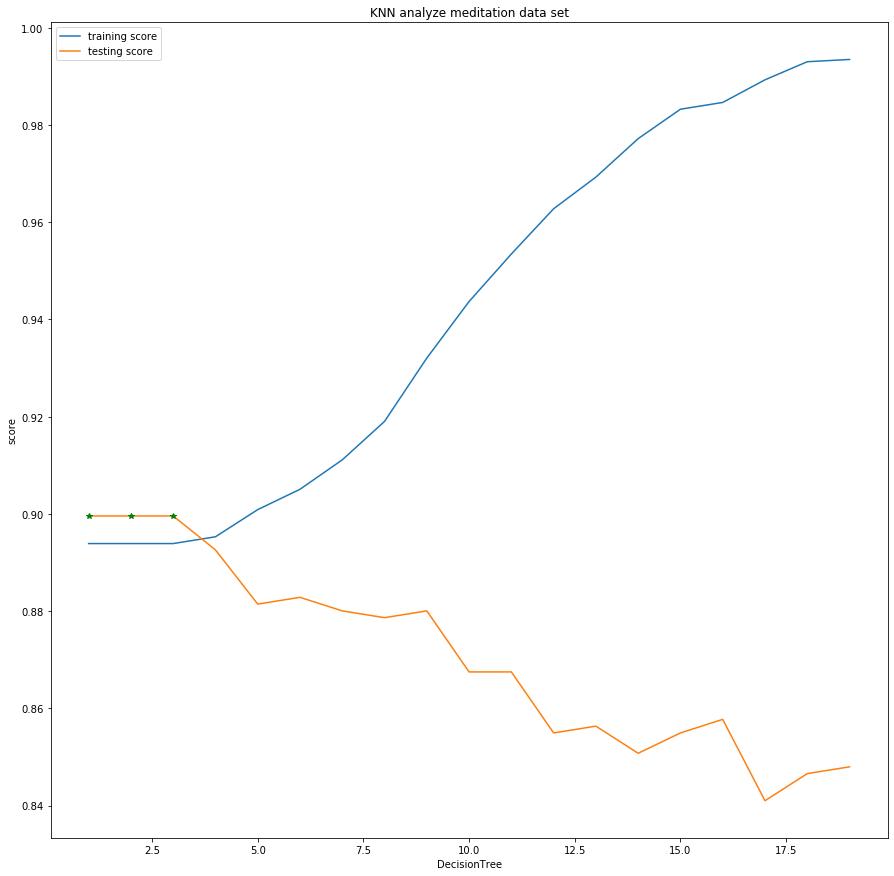

```python
tree_depth = range(1,20)
""" :brief  DecisionTree  DataSet Analyzer
    :param dataset:
        input data set
    :note Dataset content is determined by the type of used library
    :param libraryFormat:
        this param determines the type of input dataset
    :note, the libraryFormat suppoorted values:
            'sklearn', 'mglearn'
    :param print_output:
        Using this feature, you can plot the ouput result on the screen
    :param plot_title:
        setting the title of plotted figure
    :retval is a pandas data frame that contains information about machine learning model
"""
def DT_DataSetAnalyzer(dataset, libraryFormat = 'sklearn', print_output = True, plot_title = 'figure'):
    #defining variables

    train_sec = []
    test_sec = []
    #the dataset must be shuffled before using
    if  libraryFormat == 'sklearn':
        dataset = [dataset['data'], dataset['target'] ]

    ml_model = {inp: val for inp,val in zip( ['Xtrain','Xtest','ytrain','ytest'],
                                                train_test_split(dataset[0] , dataset[1],random_state = 1) ) }

    #test and training our dataset in the KNN Classifier and calculate score of tested data
    for tree_depth_num in tree_depth:
        knn = DecisionTreeClassifier(max_depth=tree_depth_num, random_state=0).fit(ml_model['Xtrain'], ml_model['ytrain'])
        test_sec.append( knn.score(ml_model['Xtest'], ml_model['ytest']) )
        train_sec.append( knn.score(ml_model['Xtrain'], ml_model['ytrain']) )
    #finding the best neighbor number for generalization
    DT_index =  findIndex(test_sec, max(test_sec))

    #(arbitrary)we can plot the model on our screen
    if(print_output):
        plt.rcParams["figure.figsize"]=15,15

        plt.figure()
        plt.title(plot_title)
        plt.plot(tree_depth, train_sec, label = 'training score')
        plt.plot(tree_depth, test_sec, label = 'testing score')
        plt.legend()
        plt.ylabel("score")
        plt.xlabel("DecisionTree")
        #inserting stars in desired positions
        for i in DT_index:
            plt.plot(tree_depth[i], test_sec[i], 'g*')

     #finally  our model reterned in 'pandas data frame' format
    return pd.DataFrame({'trainScore': map( (lambda x:( str(x*100)+'%') ),train_sec) ,
                         'testScore':  map( (lambda x:( str(x*100)+'%') ),test_sec),
                         'tree_depth' : tree_depth,
                         'best_tree_depth': extendArr(len(test_sec), DT_index)
                        })


# analyze data
knn_score = DT_DataSetAnalyzer(meditation_dataset, plot_title = 'KNN analyze meditation data set')
display(knn_score)
```

### --finding the Sweet Spot with LinearSVC

|  | trainScore | testScore | Cval | bestCval |
| --- | --- | --- | --- | --- |
| 0 | 89.3438808748255% | 89.9581589958159% | 1.000000e-07 | The best choices |
| 1 | 89.3438808748255% | 89.9581589958159% | 1.000000e-05 | The best choices |
| 2 | 89.3438808748255% | 89.9581589958159% | 1.000000e-04 | The best choices |
| 3 | 89.3438808748255% | 89.9581589958159% | 1.000000e-03 | The best choices |
| 4 | 88.97161470451373% | 89.5397489539749% | 1.000000e-02 |  |
| 5 | 89.39041414611447% | 89.9581589958159% | 1.000000e-01 | The best choices |
| 6 | 71.52163797114937% | 70.29288702928869% | 1.000000e+00 |  |
| 7 | 84.96975337366217% | 84.79776847977685% | 5.000000e+00 |  |
| 8 | 83.29455560725918% | 84.10041841004184% | 1.000000e+01 |  |
| 9 | 87.3894834806887% | 87.72663877266388% | 5.000000e+00 |  |
| 10 | 78.5481619357841% | 78.52161785216178% | 5.000000e+01 |  |
| 11 | 89.29734760353652% | 89.6792189679219% | 1.000000e+02 |  |
| 12 | 89.39041414611447% | 89.9581589958159% | 5.000000e+02 | The best choices |
| 13 | 87.99441600744532% | 88.14504881450488% | 1.000000e+03 |  |
| 14 | 89.25081433224756% | 89.9581589958159% | 1.000000e+04 | The best choices |

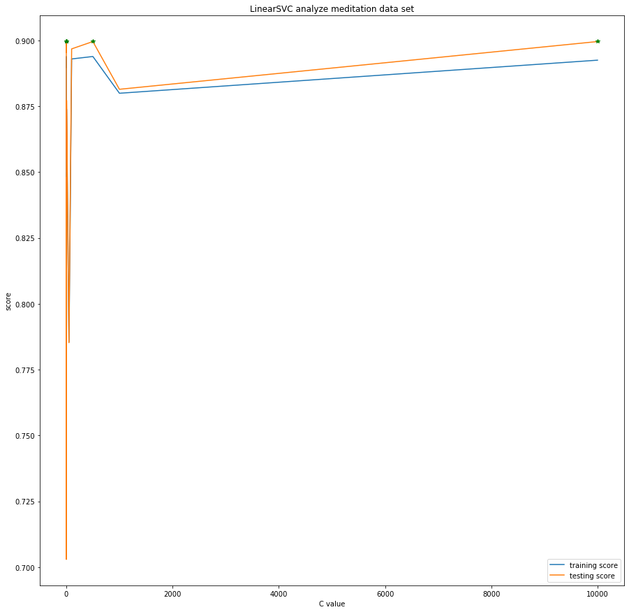

```python
c_param_set = [.0000001,.00001,.0001, .001, .01, .1, 1, 5, 10, 5, 50, 100, 500, 1000, 10000]
max_iter_set = [10000000,10000,1000, 100, 1, 1, 1, 1, 1, 1, 1, 1, 1, 1, 1]

""" :brief  LogisticRegression  DataSet Analyzer
    :param dataset:
        input data set
    :note Dataset content is determined by the type of used library
    :param libraryFormat:
        this param determines the type of input dataset
    :note, the libraryFormat suppoorted values:
            'klearn', 'mglearn'
    :param print_output:
        Using this feature, you can plot the ouput result on the screen
    :param plot_title:
        setting the title of plotted figure
    :retval is a pandas data frame that contains information about machine learning model
"""
def LR_DataSetAnalyzer(dataset, libraryFormat = 'sklearn', print_output = True, plot_title = 'figure'):
    #defining variables
    train_sec = []
    test_sec = []
    #the dataset must be shuffled before using
    if  libraryFormat == 'sklearn':
        dataset = [dataset['data'], dataset['target'] ]

    ml_model = {inp: val for inp,val in zip( ['Xtrain','Xtest','ytrain','ytest'],
                                                train_test_split(dataset[0] , dataset[1],random_state = 1) ) }

    #test and training our dataset in the KNN Classifier and calculate score of tested data
    for c_param,iter_val in zip(c_param_set, max_iter_set):
        LR = LinearSVC(C = c_param, max_iter = iter_val, penalty='l2',).fit(ml_model['Xtrain'], ml_model['ytrain'])
        test_sec.append( LR.score(ml_model['Xtest'], ml_model['ytest']) )
        train_sec.append( LR.score(ml_model['Xtrain'], ml_model['ytrain']) )
    #finding the C number for generalization
    LR_index =  findIndex(test_sec, max(test_sec))

    #(arbitrary)we can plot the model on our screen
    if(print_output):
        plt.rcParams["figure.figsize"]=15,15

        plt.figure()
        plt.title(plot_title)
        plt.plot(c_param_set, train_sec, label = 'training score')
        plt.plot(c_param_set, test_sec, label = 'testing score')
        plt.legend()
        plt.ylabel("score")
        plt.xlabel("C value")
        #inserting stars in desired positions
        for i in LR_index:
            plt.plot(c_param_set[i], test_sec[i], 'g*')

     #finally  our model reterned in 'pandas data frame' format
    return pd.DataFrame({'trainScore': map( (lambda x:( str(x*100)+'%') ),train_sec) ,
                         'testScore':  map( (lambda x:( str(x*100)+'%') ),test_sec),
                         'Cval' : c_param_set,
                         'bestCval': extendArr(len(test_sec), LR_index)
                        })


# analyze data
LR_score = LR_DataSetAnalyzer(meditation_dataset, plot_title = 'LinearSVC analyze meditation data set')
display(LR_score)
```

above data is highly scattered and inappropriate. we change features and targets in follow way(model 1)  
this is a classification problem to finding maditators during meditation We defined the features and target names as follows:  
features: frequency domain  
target names: meditator, normal  
Note that the Heart Rate Oscillations during Meditation database collected 58 instance and it must be shuffled before training

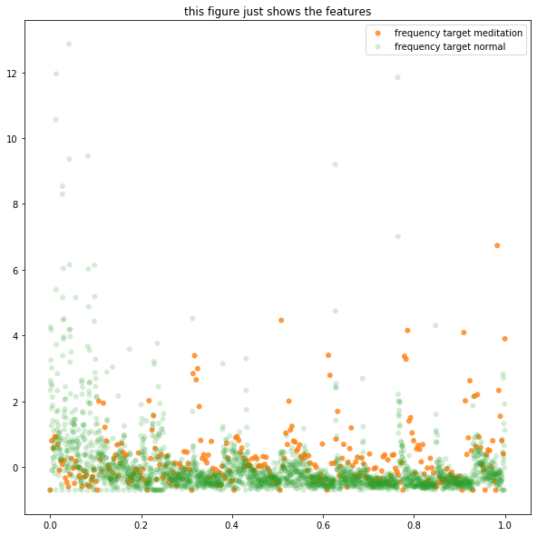

```python
#reshaping to sklearn standard data set
#note for normalization we must take care about number of data in data_arr
#note the number of data in data_arr must be equal to size of fft buffer
#[ freq]

data = []
for instance in data_arr.keys():
    for freq in  spectral_arr[instance]['domain']:
        data.append([freq, (len(instance) > 2 and  instance[3:] == 'med') * 1 ])
data = np.array(data)
meditation_dataset = {
    'data': preprocessing.scale( data[:, 0].reshape(len(data), 1) ), #[amp, freq]
    'target': data[:, 1].astype('int'),
    'feature_name':['frequency'],
    'target_name':['normal', 'meditator']
}
#see the result
#rint(meditation_dataset)

data_med = meditation_dataset['data'][(meditation_dataset['target']==1)]
data_norm = meditation_dataset['data'][(meditation_dataset['target']==0)]

tar_range = np.linspace(0,1,np.sum(meditation_dataset['target']==1))
ax = plt.subplots(figsize=(10,10))[1]

color = 'tab:orange'

title = meditation_dataset['feature_name'][0]
ax.scatter(tar_range, data_med[:, 0] , label=title + ' target meditation',
                   alpha=0.8, c=color,  edgecolors='none')

tar_range = np.linspace(0,1,np.sum(meditation_dataset['target']==0))

color = 'tab:green'

title = meditation_dataset['feature_name'][0]
ax.scatter(tar_range, data_norm[:, 0] , label=title + ' target normal',
            alpha=0.2, c=color,  edgecolors='none')

plt.legend()
plt.title('this figure just shows the features')
plt.show()
```

### --finding the Sweet Spot with KNN classifier

|  | trainScore | testScore | neighborRange | bestNeighbor |
| --- | --- | --- | --- | --- |
| 0 | 99.95346672871102% | 84.23988842398884% | 1 |  |
| 1 | 90.92601209865053% | 89.5397489539749% | 2 |  |
| 2 | 91.20521172638436% | 87.16875871687587% | 3 |  |
| 3 | 90.36761284318288% | 88.70292887029288% | 4 |  |
| 4 | 90.3210795718939% | 88.28451882845188% | 5 |  |
| 5 | 90.04187994416007% | 89.2608089260809% | 6 |  |
| 6 | 90.27454630060492% | 88.8423988842399% | 7 |  |
| 7 | 89.94881340158213% | 89.1213389121339% | 8 |  |
| 8 | 89.99534667287111% | 88.98186889818689% | 9 |  |
| 9 | 89.71614704513728% | 89.8186889818689% | 10 |  |
| 10 | 89.6696137738483% | 89.8186889818689% | 11 |  |
| 11 | 89.57654723127035% | 89.6792189679219% | 12 |  |
| 12 | 89.57654723127035% | 89.40027894002789% | 13 |  |
| 13 | 89.48348068869242% | 89.9581589958159% | 14 |  |
| 14 | 89.48348068869242% | 89.8186889818689% | 15 |  |
| 15 | 89.43694741740345% | 90.0976290097629% | 16 | The best choices |
| 16 | 89.48348068869242% | 89.9581589958159% | 17 |  |
| 17 | 89.39041414611447% | 89.9581589958159% | 18 |  |
| 18 | 89.39041414611447% | 89.9581589958159% | 19 |  |

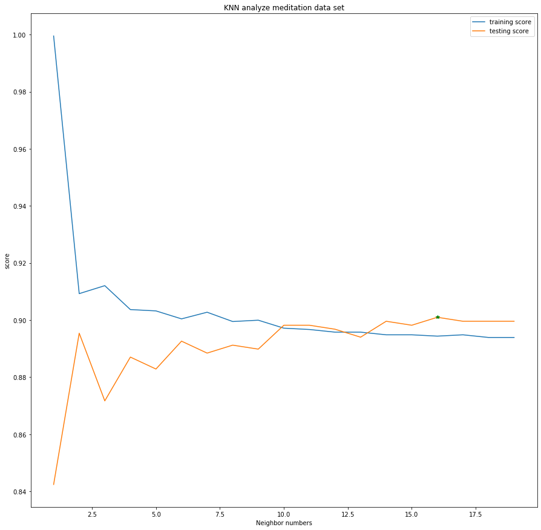

```python
knn_score = KNN_DataSetAnalyzer(meditation_dataset, plot_title = 'KNN analyze meditation data set')
display(knn_score)
```

|  | trainScore | testScore | Cval | bestCval |
| --- | --- | --- | --- | --- |
| 0 | 89.39041414611447% | 89.9581589958159% | 1.000000e-07 | The best choices |
| 1 | 89.39041414611447% | 89.9581589958159% | 1.000000e-05 | The best choices |
| 2 | 89.39041414611447% | 89.8186889818689% | 1.000000e-04 |  |
| 3 | 89.39041414611447% | 89.8186889818689% | 1.000000e-03 |  |
| 4 | 89.3438808748255% | 89.6792189679219% | 1.000000e-02 |  |
| 5 | 87.29641693811075% | 87.16875871687587% | 1.000000e-01 |  |
| 6 | 89.39041414611447% | 89.9581589958159% | 1.000000e+00 | The best choices |
| 7 | 89.39041414611447% | 89.9581589958159% | 5.000000e+00 | The best choices |
| 8 | 88.45974872033504% | 88.98186889818689% | 1.000000e+01 |  |
| 9 | 85.38855281526291% | 84.93723849372385% | 5.000000e+00 |  |
| 10 | 89.29734760353652% | 89.6792189679219% | 5.000000e+01 |  |
| 11 | 89.39041414611447% | 89.9581589958159% | 1.000000e+02 | The best choices |
| 12 | 88.13401582131223% | 88.14504881450488% | 5.000000e+02 |  |
| 13 | 89.39041414611447% | 89.9581589958159% | 1.000000e+03 | The best choices |
| 14 | 87.3894834806887% | 87.44769874476988% | 1.000000e+04 |  |

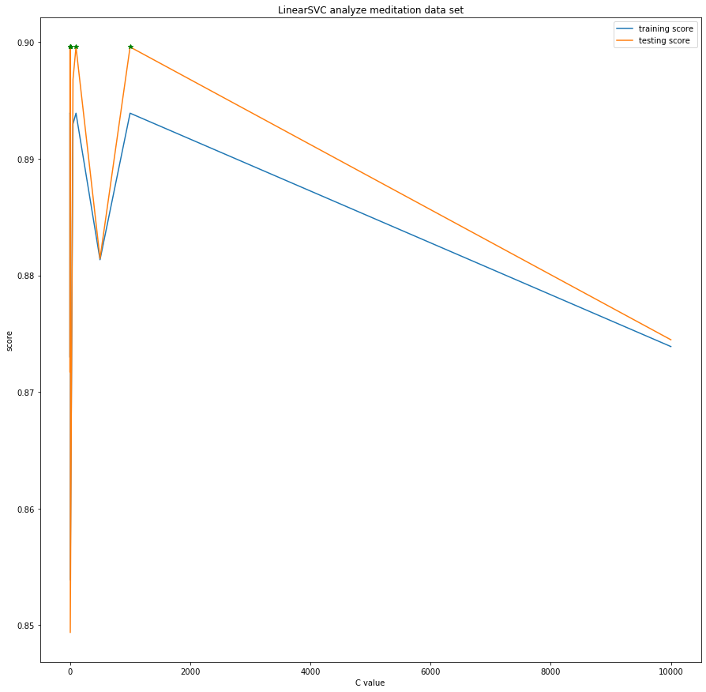

```python
max_iter_set = [1000000,100000,10000, 1000, 1, 1, 1, 1, 1, 1, 1, 1, 1, 1, 1]
LR_score = LR_DataSetAnalyzer(meditation_dataset, plot_title = 'LinearSVC analyze meditation data set')
display(LR_score)
```

### --finding the Sweet Spot with DecisionTree

|  | trainScore | testScore | tree_depth | best_tree_depth |
| --- | --- | --- | --- | --- |
| 0 | 89.39041414611447% | 89.9581589958159% | 1 | The best choices |
| 1 | 89.39041414611447% | 89.9581589958159% | 2 | The best choices |
| 2 | 89.39041414611447% | 89.9581589958159% | 3 | The best choices |
| 3 | 89.6696137738483% | 89.40027894002789% | 4 |  |
| 4 | 90.04187994416007% | 87.86610878661088% | 5 |  |
| 5 | 90.3210795718939% | 88.8423988842399% | 6 |  |
| 6 | 90.69334574220568% | 88.42398884239888% | 7 |  |
| 7 | 91.06561191251745% | 88.56345885634589% | 8 |  |
| 8 | 91.53094462540716% | 88.56345885634589% | 9 |  |
| 9 | 91.90321079571893% | 88.56345885634589% | 10 |  |
| 10 | 92.41507677989763% | 88.42398884239888% | 11 |  |
| 11 | 92.69427640763146% | 88.28451882845188% | 12 |  |
| 12 | 93.20614239181015% | 87.58716875871687% | 13 |  |
| 13 | 93.57840856212192% | 87.86610878661088% | 14 |  |
| 14 | 94.18334108887855% | 86.75034867503487% | 15 |  |
| 15 | 94.78827361563518% | 86.61087866108787% | 16 |  |
| 16 | 95.34667287110284% | 85.91352859135286% | 17 |  |
| 17 | 96.04467194043741% | 85.77405857740585% | 18 |  |
| 18 | 96.51000465332713% | 85.91352859135286% | 19 |  |

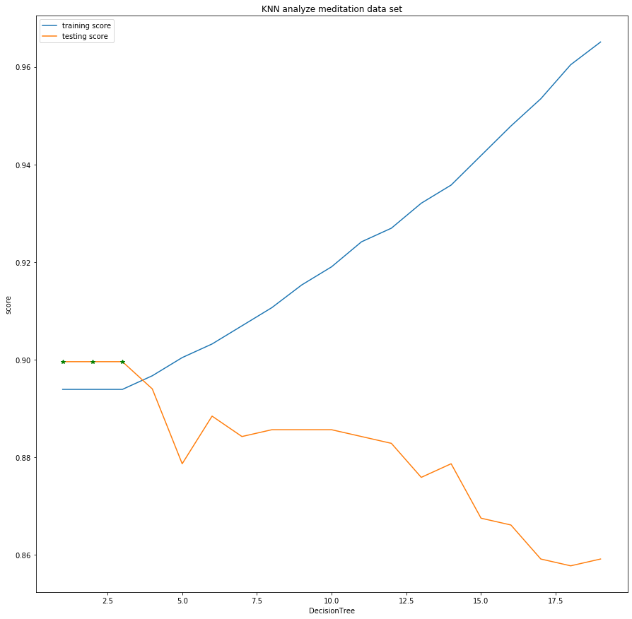

```python
# analyze data
knn_score = DT_DataSetAnalyzer(meditation_dataset, plot_title = 'KNN analyze meditation data set')
display(knn_score)
```

we change features and targets in follow way(model 2)  
this is a classification problem to finding maditators during meditation We defined the features and target names as follows:  
features: List the average frequency range, 'mean bpm of heart rate', 'time variance of heart rate', 'max bpm of heart rate'  
target names: meditator, normal  
Note that the Heart Rate Oscillations during Meditation database collected 58 instance and it must be shuffled before training  
Note that you can easily change the length of the "the average frequency range"array by changing the "precision" variable in the following program.

|  | freq_0.05 | freq_0.10 | freq_0.15 | freq_0.21 | freq_0.26 | freq_0.31 | freq_0.36 | freq_0.42 | freq_0.47 | freq_0.52 | ... | freq_0.68 | freq_0.73 | freq_0.78 | freq_0.84 | freq_0.89 | freq_0.94 | freq_1.0 | mean_bpm | time_variance | max_bpm |
| --- | --- | --- | --- | --- | --- | --- | --- | --- | --- | --- | --- | --- | --- | --- | --- | --- | --- | --- | --- | --- | --- |
| 0 | 0.378414 | 1.294957 | 2.159271 | 1.803907 | 0.919732 | 2.970635 | 1.090996 | 3.638758 | 1.770253 | 1.613761 | ... | 1.190941 | 2.930943 | 1.803105 | 1.101515 | 2.311581 | 0.821883 | 3.791985 | 0.233034 | 0.691076 | 0.765394 |
| 1 | -0.192193 | 0.023688 | 0.403410 | -0.114398 | -0.076754 | 0.241535 | -0.671395 | -0.611114 | 0.351747 | -0.185677 | ... | -0.283758 | 0.050982 | -0.289519 | -0.276304 | -0.648973 | 0.120778 | 1.015651 | 0.424437 | 0.239227 | -0.093217 |
| 2 | 3.428536 | 3.760649 | 1.744985 | 0.491407 | 1.100405 | 1.972717 | 1.214912 | 1.760843 | 1.717076 | -0.463067 | ... | 1.299836 | 2.306856 | 1.459326 | 0.985484 | 2.193778 | -0.432810 | 2.430711 | 1.144363 | 2.328192 | 1.256798 |
| 3 | 0.254101 | -0.305202 | 0.897616 | 0.198539 | -0.235903 | -0.257581 | 0.042484 | 1.137292 | 0.191605 | 0.750549 | ... | -0.685148 | 0.021484 | 0.018014 | 0.307158 | 1.123828 | 0.508475 | 0.086050 | 1.032631 | -0.379941 | 0.508915 |
| 4 | 2.588793 | 2.482671 | 3.335593 | 2.836426 | 2.257967 | 2.731140 | 1.327486 | 2.932075 | 2.457357 | 2.897223 | ... | 0.733234 | 1.533885 | 0.567388 | 1.705673 | 1.904901 | 0.925910 | 1.465037 | 1.163157 | 2.972103 | 2.104183 |

5 rows × 22 columns

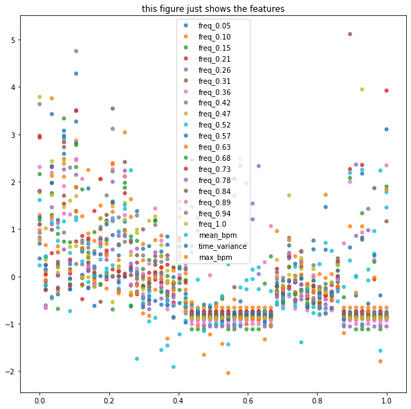

```python
#reshaping to sklearn standard data set
#note for normalization we must take care about number of data in data_arr
#note the number of data in data_arr must be equal to size of fft buffer
#[amp, freq]



precision = 20
frequency_scale = 1
freq_range = np.linspace(0,high_freq,precision)

data = []
target = []
for instance,j in zip(data_arr.keys(), range( len(data_arr.keys()) )):
    data.append([])
    target.append((len(instance) > 2 and  instance[3:] == 'med') * 1)
    #adding frequency data
    for i in range(1,len(freq_range)):
        #adding frequency data
        ax = spectral_arr[instance]['axis']
        data[j].append(
                    np.mean( spectral_arr[instance]['domain'][
                            np.logical_and(ax<freq_range[i] , ax>freq_range[i-1])   ]
                           )*frequency_scale
        )
     #adding time data
    data[j].extend([
        np.mean( data_arr[instance]['data'] ),
        np.var( data_arr[instance]['data'] ),
        np.max( data_arr[instance]['data'] )
    ])

data = np.array(data); target = np.array(target).astype('int')
data[np.isnan(data)] = 0


meditation_dataset = {
    'data': data, #[amp, freq]
    'target': target,
    'target_names': list(data_arr.keys()),
    'feature_name': ['freq_' + str(i)[:4] for i in freq_range[1:] ] + ['mean_bpm', 'time_variance', 'max_bpm'],
    'target_name':['normal', 'meditator']
}
#normalize data mean, variance and maximum
#for i in range(3):
#    meditation_dataset['data'][: ,len(meditation_dataset['feature_name'])-3 + i] = \
#    data[ : , len(meditation_dataset['feature_name'])-3 + i] - np.mean(data[ : , len(meditation_dataset['feature_name'])-3 + i])
data = preprocessing.scale(data)


#see the result
df =  pd.DataFrame( data[:5,:], columns= meditation_dataset['feature_name'] )
display(df)

tar_range = np.linspace(0,1,len(target))
ax = plt.subplots(figsize=(10,10))[1]

for j in range( len(meditation_dataset['feature_name']) ):
        title = meditation_dataset['feature_name'][j]
        ax.scatter(tar_range, data[:, j] , label=title,
                   alpha=0.8, edgecolors='none')
plt.legend()
plt.title('this figure just shows the features')
plt.show()
```

### --finding the Sweet Spot with KNN classifier

|  | trainScore | testScore | neighborRange | bestNeighbor |
| --- | --- | --- | --- | --- |
| 0 | 100.0% | 80.0% | 1 |  |
| 1 | 81.3953488372093% | 86.66666666666667% | 2 |  |
| 2 | 86.04651162790698% | 100.0% | 3 | The best choices |
| 3 | 81.3953488372093% | 93.33333333333333% | 4 |  |
| 4 | 86.04651162790698% | 86.66666666666667% | 5 |  |
| 5 | 86.04651162790698% | 93.33333333333333% | 6 |  |
| 6 | 81.3953488372093% | 93.33333333333333% | 7 |  |
| 7 | 79.06976744186046% | 86.66666666666667% | 8 |  |
| 8 | 76.74418604651163% | 93.33333333333333% | 9 |  |
| 9 | 81.3953488372093% | 86.66666666666667% | 10 |  |
| 10 | 79.06976744186046% | 93.33333333333333% | 11 |  |
| 11 | 79.06976744186046% | 93.33333333333333% | 12 |  |
| 12 | 81.3953488372093% | 93.33333333333333% | 13 |  |
| 13 | 81.3953488372093% | 93.33333333333333% | 14 |  |
| 14 | 81.3953488372093% | 93.33333333333333% | 15 |  |
| 15 | 76.74418604651163% | 86.66666666666667% | 16 |  |
| 16 | 76.74418604651163% | 86.66666666666667% | 17 |  |
| 17 | 76.74418604651163% | 86.66666666666667% | 18 |  |
| 18 | 76.74418604651163% | 86.66666666666667% | 19 |  |

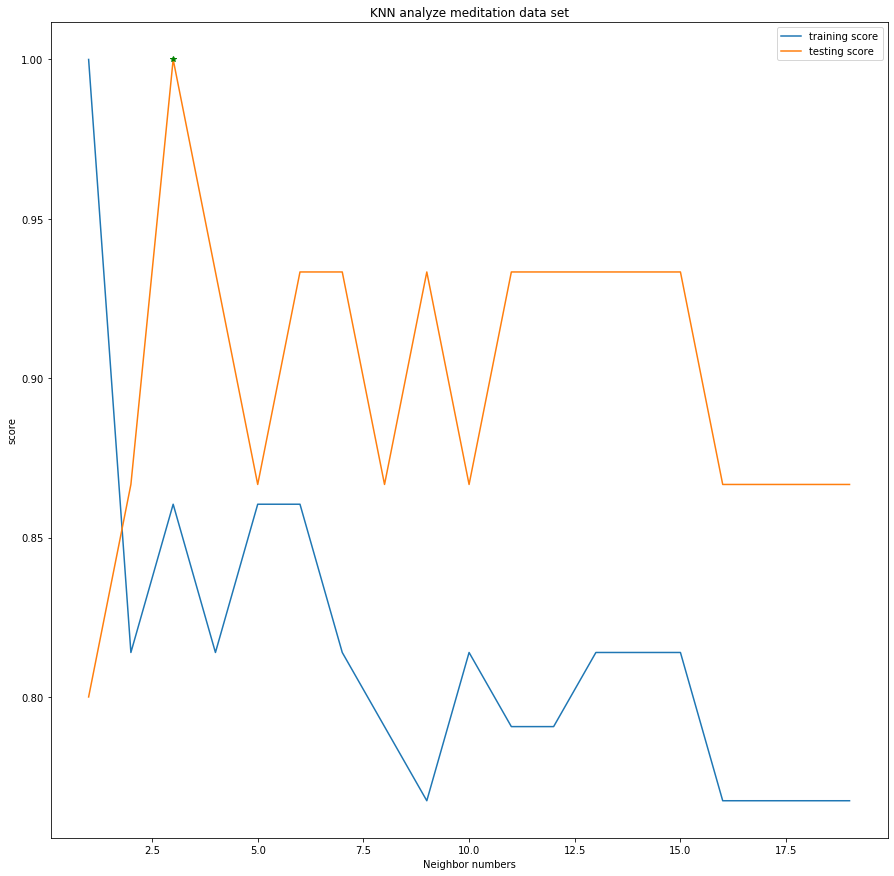

```python
# analyze data
knn_score = KNN_DataSetAnalyzer(meditation_dataset, plot_title = 'KNN analyze meditation data set')
display(knn_score)
```

|  | trainScore | testScore | Cval | bestCval |
| --- | --- | --- | --- | --- |
| 0 | 76.74418604651163% | 86.66666666666667% | 1.000000e-07 | The best choices |
| 1 | 76.74418604651163% | 86.66666666666667% | 1.000000e-05 | The best choices |
| 2 | 76.74418604651163% | 86.66666666666667% | 1.000000e-04 | The best choices |
| 3 | 79.06976744186046% | 86.66666666666667% | 1.000000e-03 | The best choices |
| 4 | 23.25581395348837% | 13.333333333333334% | 1.000000e-02 |  |
| 5 | 23.25581395348837% | 13.333333333333334% | 1.000000e-01 |  |
| 6 | 76.74418604651163% | 86.66666666666667% | 1.000000e+00 | The best choices |
| 7 | 23.25581395348837% | 13.333333333333334% | 5.000000e+00 |  |
| 8 | 76.74418604651163% | 86.66666666666667% | 1.000000e+01 | The best choices |
| 9 | 76.74418604651163% | 86.66666666666667% | 5.000000e+00 | The best choices |
| 10 | 74.4186046511628% | 86.66666666666667% | 5.000000e+01 | The best choices |
| 11 | 76.74418604651163% | 86.66666666666667% | 1.000000e+02 | The best choices |
| 12 | 76.74418604651163% | 86.66666666666667% | 5.000000e+02 | The best choices |
| 13 | 23.25581395348837% | 13.333333333333334% | 1.000000e+03 |  |
| 14 | 76.74418604651163% | 86.66666666666667% | 1.000000e+04 | The best choices |

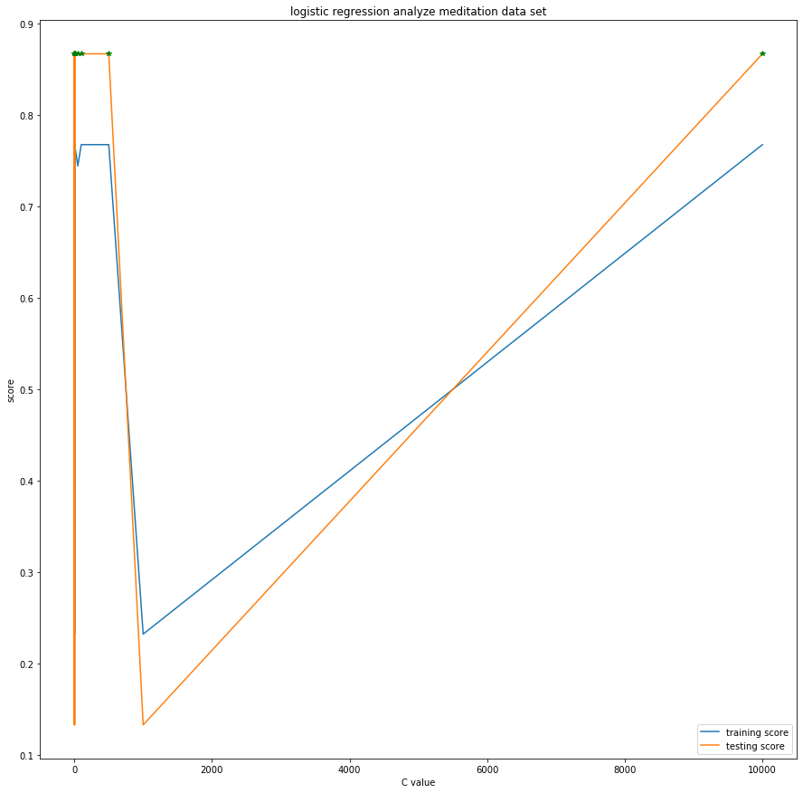

```python
max_iter_set = [10000000,100000,10000, 1000, 1, 1, 1, 1, 1, 1, 1, 1, 1, 1, 1]

# analyze data
LR_score = LR_DataSetAnalyzer(meditation_dataset, plot_title = 'logistic regression analyze meditation data set')
display(LR_score)
```

### --finding the Sweet Spot with DecisionTree

|  | trainScore | testScore | tree_depth | best_tree_depth |
| --- | --- | --- | --- | --- |
| 0 | 76.74418604651163% | 86.66666666666667% | 1 |  |
| 1 | 93.02325581395348% | 80.0% | 2 |  |
| 2 | 97.67441860465115% | 100.0% | 3 | The best choices |
| 3 | 100.0% | 100.0% | 4 | The best choices |

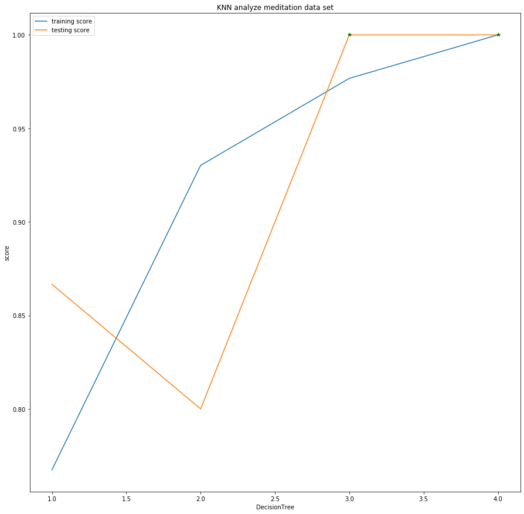

```python
tree_depth = range(1,5)
# analyze data
knn_score = DT_DataSetAnalyzer(meditation_dataset, plot_title = 'KNN analyze meditation data set')
display(knn_score)
```